# Lab4_notebook

## **B18030-Tushar Goyal_CSE**

### Multivariate Gaussian Random Vector Generator

###### This is one of the most useful tool in data generation. Most of the times, we know that there is some correlation between the features of the data and we want to sample a n-dimensional random vector from above distribution characterized by mean vector μ and co-variance matrix Σ.

##### A univariate distribution is suitable when we want to express our uncertainty over a quantity like adult weight. What if we want to express our uncertainty over multiple quantities (joint random variables — adult weight and height)?

- numpy.random.multivariate_normal

**numpy.random.multivariate_normal(mean, cov[, size, check_valid, tol])**

Draw random samples from a multivariate normal distribution.

- The multivariate normal, multinormal or Gaussian distribution is a generalization of the one-dimensional normal distribution to higher dimensions. Such a distribution is specified by its mean and covariance matrix.

##### Generate 1000 samples each with 2 dimensions, say this data matrix D. Each sample is independently and identically distributed with multi-variate (multi >= 2 dimensions) Gaussian distribution with user entered mean values and covariance matrix

```python
from numpy import array
from numpy import mean
from numpy import cov
from numpy.linalg import eig
from numpy import matmul
import seaborn as sns
```

```
Enter mean: 0 0
Enter 1st row of cov matrix:
7 10
Enter 2nd row of cov matrix:
10 18
```

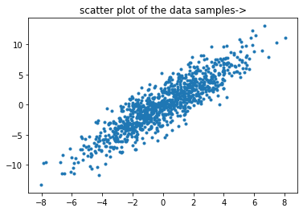

```
size of D in bytes:  16056
```

```python
import sys
import numpy as np
import pandas as pd
import matplotlib.pyplot as plt

a,b=input("Enter mean: ").split()
a,b=int(a),int(b)
mean=[a,b]
print("Enter 1st row of cov matrix:")
c1=[int(x) for x in input().split()]
print("Enter 2nd row of cov matrix:")
c2=[int(x) for x in input().split()]
Cov_mat=[c1,c2]
np.random.seed(0)
D = pd.DataFrame(np.random.multivariate_normal(mean, Cov_mat, 1000), columns = ['A', 'B'])
plt.scatter(D.A, D.B,marker='.')
plt.title("scatter plot of the data samples->")
plt.show()
print("\nsize of D in bytes: ", sys.getsizeof(D))
```

#### Inferences:

- Scatter plot is **centered at (mean1,mean2) and dispersed according to the cov matrix.**
- **Eigenvectors would be along the directions in which there is max dispersion of data**

```python
D.head()
```

|  | A | B |
| --- | --- | --- |
| 0 | -4.749628 | -7.213088 |
| 1 | -4.447294 | -2.930557 |
| 2 | -3.770890 | -8.379793 |
| 3 | -2.228772 | -4.079550 |
| 4 | -0.111646 | 0.652389 |

```python
D.values
```

```
array([[-4.74962803, -7.21308835],
       [-4.44729371, -2.9305568 ],
       [-3.77089022, -8.37979316],
       ...,
       [-0.58010264, -0.78084424],
       [-3.63038446, -5.8153739 ],
       [ 4.01870969,  4.11088152]])
```

```python
meanA,meanB=list(D.mean())
```

```python
meanA
```

```
0.06298771630321233
```

**Covariance Matrix** :

- The covariance is defined as the measure of the joint variability of two random variables

```python
X=D-D.mean()
X_T=X.T
C=matmul(X_T.values,X.values)/999
```

```python
C
```

```
array([[ 6.60465883,  9.4641473 ],
       [ 9.4641473 , 17.17041334]])
```

```python
import seaborn as sns
```

##### After the covariance matrix is generated, eigendecomposition is performed on the covariance matrix. Eigenvectors and eigenvalues are found as a result of the eigendceomposition. Each eigenvector has a corresponding eigenvalue, and the sum of the eigenvalues represents all of the variance within the entire dataset

The numpy.linalg.eig function returns a tuple consisting of a vector[vector of eigen values] and an array. The vector contains the eigenvalues. The array contains the corresponding eigenvectors, one eigenvector per column. The eigenvectors are normalized so their Euclidean norms are 1 .

```python
# eigen decomposition of covariance matrix
eigen_vals, eigen_vecs = eig(Cov_mat)
print(eigen_vecs)
print("Eigen values array is :",end="")
print(eigen_vals)
vec1, vec2 = eigen_vecs[:, 0], eigen_vecs[:, 1]
```

```
[[-0.86078997 -0.50896034]
 [ 0.50896034 -0.86078997]]
Eigen values array is :[ 1.08728779 23.91271221]
```

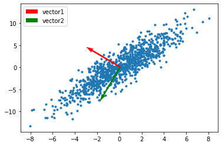

```python
qt=eigen_vecs.transpose()
plt.scatter(D.A, D.B,marker='.')
plt.quiver(meanA,meanB,vec1[0],vec1[1],scale=5,color='r',label="vector1")
plt.quiver(meanA,meanB,vec2[0],vec2[1],scale=5,color='g',label="vector2")
plt.legend()
```

**PROBLEM 2**

- Compute a matrix A belonging to R(2x1) such that DxA = ~D. Here D is the data matrix with data samples in its columns (2 dimensions) and ~D represents the matrix with reduced dimensions (1 dimension). How can you generate such matrix A? Compute the reconstruction error between ~D obtained using (your generated) A, and D using mean square error. Hint: Think of A as A = [a1 a2], and a1 & a2 as the weights to the first and second column of matrix D respectively, while multiplying D with A.

```python
sum1 = sum(D.A)
sum2 = sum(D.B)
A = np.array([sum1/(sum1+sum2), sum2/(sum1+sum2)])
print("\nA matrix :\n ", A)


D_red = np.matmul(np.array(D.values), A.T)
D2 = pd.DataFrame([D_red[i] * A for i in range(1000)], columns = ['A', 'B'])
print(D2.head())
```

```
A matrix :
  [0.42209129 0.57790871]
          A         B
0 -2.605689 -3.567594
1 -1.507186 -2.063572
2 -2.715911 -3.718505
3 -1.392206 -1.906147
4  0.139246  0.190650
```

```python
D.shape
```

```
(1000, 2)
```

```python
type(D)
```

```
pandas.core.frame.DataFrame
```

```python
error=np.sum(np.square(D-D2))
error/1000
```

[output not shown]

[figure not shown]

```python
Dt=pd.DataFrame(columns=['A','B'])
```

```python
Dt
```

|  | A | B |
| --- | --- | --- |

```python
D.T.head()
```

|  | 0 | 1 | 2 | 3 | 4 | 5 | 6 | 7 | 8 | 9 | ... | 990 | 991 | 992 | 993 | 994 | 995 | 996 | 997 | 998 | 999 |
| --- | --- | --- | --- | --- | --- | --- | --- | --- | --- | --- | --- | --- | --- | --- | --- | --- | --- | --- | --- | --- | --- |
| A | -4.749628 | -4.447294 | -3.770890 | -2.228772 | -0.111646 | -1.663818 | -2.003319 | -1.404205 | -3.534391 | -0.012565 | ... | 1.962835 | 1.144808 | 2.853051 | -1.004055 | 3.109730 | -2.677436 | -2.982851 | -0.580103 | -3.630384 | 4.018710 |
| B | -7.213088 | -2.930557 | -8.379793 | -4.079550 | 0.652389 | 0.165471 | -3.138875 | -1.691277 | -6.397931 | -1.771077 | ... | 3.322244 | 0.231710 | 1.711107 | -1.780117 | 5.318033 | -6.044212 | -5.707493 | -0.780844 | -5.815374 | 4.110882 |

2 rows × 1000 columns

```python
Dt.A=np.matmul(np.array(D.values),vec1.T)#first principal component of each data point
Dt.B=np.matmul(np.array(D.values),vec2.T)#second principal component of each data point
```

```python
Dt.head()
```

|  | A | B |
| --- | --- | --- |
| 0 | 0.417256 | 8.626326 |
| 1 | 2.336649 | 4.786090 |
| 2 | -1.019038 | 9.132475 |
| 3 | -0.157825 | 4.645992 |
| 4 | 0.428144 | -0.504747 |

```python
D_rec = pd.DataFrame(np.random.randn(1000, 2),columns = ['A', 'B'])
#Reconstruct the data samples using all eigenvectors.
for i in range(1000):
    D_rec.iloc[i] = Dt.iloc[i][0] * vec1 + Dt.iloc[i][1] * vec2
```

```python
error=np.sum(np.square(D_rec-D))
error/1000
```

```
A    4.037952e-31
B    1.027120e-30
dtype: float64
```

```python
X=Dt-Dt.mean()
X_T=X.T
C=matmul(X_T.values,X.values)/1000
```

```python
C
```

```
array([[ 1.04793308, -0.06792307],
       [-0.06792307, 22.70336403]])
```

## **Inferences:**

**As it is clear that eigenvalues are same as the variances in the covariance matrix of transformed data.**

**Also, for dimensional reduction, we would use the eigen vector parallel to the direction of max dispersion.**

**That is the eigenvector corresponding to the larger eigenvalue.**

#### The common approach is to rank the eigenvectors from highest to lowest corresponding eigenvalue and choose the top k eigenvectors to have the final dimension as k.

```python
D_rec1 = pd.DataFrame(np.random.randn(1000, 2),columns = ['A', 'B'])
for i in range(1000):
    D_rec1.iloc[i] = Dt.iloc[i][0] * vec1
```

```python
D_rec1.head()
```

|  | A | B |
| --- | --- | --- |
| 0 | -0.359170 | 0.212367 |
| 1 | -2.011364 | 1.189261 |
| 2 | 0.877178 | -0.518650 |
| 3 | 0.135854 | -0.080327 |
| 4 | -0.368542 | 0.217908 |

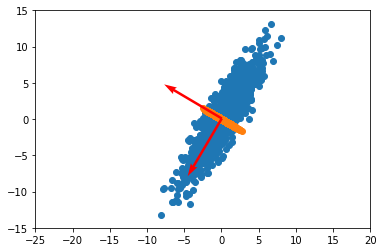

```python
plt.xlim([-25,20])
plt.ylim([-15,15])

plt.scatter(D.A,D.B)
plt.scatter(D_rec1.A,D_rec1.B)
plt.quiver(meanA,meanB,vec1[0],vec1[1],scale=5,color='r')
plt.quiver(meanA,meanB,vec2[0],vec2[1],scale=5,color='r')
plt.show()
```

```python
D_rec2 = pd.DataFrame(np.random.randn(1000, 2),columns = ['A', 'B'])
for i in range(1000):
    D_rec2.iloc[i] = Dt.iloc[i][1] * vec2
```

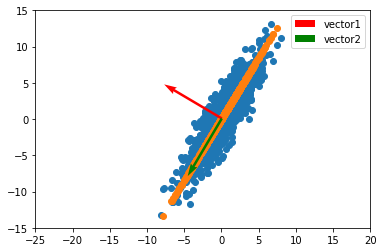

```python
plt.xlim([-25,20])
plt.ylim([-15,15])
plt.scatter(D.A,D.B)
plt.scatter(D_rec2.A,D_rec2.B)
plt.quiver(meanA,meanB,vec1[0],vec1[1],scale=5,color='r',label="vector1")
plt.quiver(meanA,meanB,vec2[0],vec2[1],scale=5,color='g',label="vector2")
plt.legend()
```

```python
print("Computing the reconstruction error for D_rec1  using mean square error ==> ")
error=np.sum(np.square(D_rec1-D))
error/1000
```

```
Computing the reconstruction error for D_rec1  using mean square error ==>
```

```
A     5.884020
B    16.830642
dtype: float64
```

```python
print("Computing the reconstruction error for D_rec2  using mean square error ==> ")
error=np.sum(np.square(D_rec2-D))
error/1000
```

```
Computing the reconstruction error for D_rec2  using mean square error ==>
```

```
A    0.776555
B    0.271485
dtype: float64
```

```python
np.savetxt("data.csv",D.values,delimiter=",")
```

```python
np.savetxt("PC_1.csv",Dt.A,delimiter=",")
```

```python
np.savetxt("PC_2.csv",Dt.B,delimiter=",")
```

```python
print("\nsize of D in bytes: ", sys.getsizeof(D))
```

```
size of D in bytes:  16056
```

```python
file1=pd.read_csv("PC_1.csv")
```

```python
print("\nsize of file1 in bytes: ", sys.getsizeof(file1))
```

```
size of file1 in bytes:  8048
```

Disadvantages of PCA =>

- PCA tends to find linear correlations between variables, which is sometimes undesirable.
- PCA fails in cases where mean and covariance are not enough to define datasets.
- We may not know how many principal components to keep- in practice, some thumb rules are applied.

Visualizing principal components of a Data Point

[figure not shown]

```python
df=D.copy()
```

```python
df.head()
```

|  | A | B |
| --- | --- | --- |
| 0 | -4.749628 | -7.213088 |
| 1 | -4.447294 | -2.930557 |
| 2 | -3.770890 | -8.379793 |
| 3 | -2.228772 | -4.079550 |
| 4 | -0.111646 | 0.652389 |

**sklearn.decomposition.PCA** **=>**

class sklearn.decomposition.PCA(n_components=None, copy=True, whiten=False, svd_solver=’auto’, tol=0.0, iterated_power=’auto’, random_state=None)

**Parameters:**

- n_components : int, float
  - Number of components to keep. if n_components is not set all components are kept: **n_components == min(n_samples, n_features)**
  - If **0 < n_components < 1** select the number of components such that the amount of variance that needs to be explained is greater than the percentage specified by n_components.

```python
from sklearn.decomposition import PCA

pca=PCA()
print(pca.fit_transform(df))
```

```
[[ 8.7312351  -0.45497044]
 [ 4.88499745 -2.36230848]
 [ 9.24188662  0.97972914]
 ...
 [ 1.07332753 -0.1156213 ]
 [ 6.95924522 -0.19735891]
 [-5.47339455  1.3738369 ]]
```

__PCA removes correlation__

**Principal Component explained variance ratio**

```python
pca.fit(df)

print("Variance ratio in eigen vectors=>")
print(pca.explained_variance_ratio_)
print("Eigen vectors found using PCA=>")
print(pca.components_)
print("Eigen vectors found using numpy and covariance matrix=>")
print(eigen_vecs)
```

[output not shown]

```
Variance ratio in eigen vectors=>
[0.95588788 0.04411212]
Eigen vectors found using PCA=>
[[-0.50625797 -0.86238209]
 [ 0.86238209 -0.50625797]]
Eigen vectors found using numpy and covariance matrix=>
[[-0.86078997 -0.50896034]
 [ 0.50896034 -0.86078997]]
```

Both procedures find the correct eigenvectors. The difference is in its representation. While PCA() lists the entries of an eigenvectors rowwise, np.linalg.eig() lists the entries of the eigenvectors columnwise. Remember that eigenvectors are only unique up to a sign.

**So Question is How many principal components to take**?

To decide how many eigenvalues/eigenvectors to keep, you should consider your reason for doing PCA in the first place. Are you doing it for reducing storage requirements, to reduce dimensionality for a classification algorithm, or for some other reason? If you don't have any strict constraints, I recommend **plotting the cumulative sum of eigenvalues (assuming they are in descending order). If you divide each value by the total sum of eigenvalues prior to plotting, then your plot will show the fraction of total variance retained vs. number of eigenvalues. The plot will then provide a good indication of when you hit the point of diminishing returns (i.e., little variance is gained by retaining additional eigenvalues).**